# WINE QUALITY PREDICTION

#Importing libraries

```r
library(caret)
library(tidyverse)
```

```r
library(corrplot)
library(keras)
library(randomForest)
library(kableExtra)
library(modelr)
library(psych)
library(Rmisc)
library(gridExtra)
library(scales)
library(rpart)
library(yardstick)
```

#Importing the Dataset

```r
winequality <- read.csv("http://archive.ics.uci.edu/ml/machine-learning-databases/wine-quality/winequality-red.csv", sep =';')
head(winequality)
```

```
##   fixed.acidity volatile.acidity citric.acid residual.sugar chlorides
## 1           7.4             0.70        0.00            1.9     0.076
## 2           7.8             0.88        0.00            2.6     0.098
## 3           7.8             0.76        0.04            2.3     0.092
## 4          11.2             0.28        0.56            1.9     0.075
## 5           7.4             0.70        0.00            1.9     0.076
## 6           7.4             0.66        0.00            1.8     0.075
##   free.sulfur.dioxide total.sulfur.dioxide density   pH sulphates alcohol
## 1                  11                   34  0.9978 3.51      0.56     9.4
## 2                  25                   67  0.9968 3.20      0.68     9.8
## 3                  15                   54  0.9970 3.26      0.65     9.8
## 4                  17                   60  0.9980 3.16      0.58     9.8
## 5                  11                   34  0.9978 3.51      0.56     9.4
## 6                  13                   40  0.9978 3.51      0.56     9.4
##   quality
## 1       5
## 2       5
## 3       5
## 4       6
## 5       5
## 6       5
```

```r
summary(winequality)
```

```
##  fixed.acidity   volatile.acidity  citric.acid    residual.sugar
##  Min.   : 4.60   Min.   :0.1200   Min.   :0.000   Min.   : 0.900
##  1st Qu.: 7.10   1st Qu.:0.3900   1st Qu.:0.090   1st Qu.: 1.900
##  Median : 7.90   Median :0.5200   Median :0.260   Median : 2.200
##  Mean   : 8.32   Mean   :0.5278   Mean   :0.271   Mean   : 2.539
##  3rd Qu.: 9.20   3rd Qu.:0.6400   3rd Qu.:0.420   3rd Qu.: 2.600
##  Max.   :15.90   Max.   :1.5800   Max.   :1.000   Max.   :15.500
##    chlorides       free.sulfur.dioxide total.sulfur.dioxide    density
##  Min.   :0.01200   Min.   : 1.00       Min.   :  6.00       Min.   :0.9901
##  1st Qu.:0.07000   1st Qu.: 7.00       1st Qu.: 22.00       1st Qu.:0.9956
##  Median :0.07900   Median :14.00       Median : 38.00       Median :0.9968
##  Mean   :0.08747   Mean   :15.87       Mean   : 46.47       Mean   :0.9967
##  3rd Qu.:0.09000   3rd Qu.:21.00       3rd Qu.: 62.00       3rd Qu.:0.9978
##  Max.   :0.61100   Max.   :72.00       Max.   :289.00       Max.   :1.0037
##        pH          sulphates         alcohol         quality
##  Min.   :2.740   Min.   :0.3300   Min.   : 8.40   Min.   :3.000
##  1st Qu.:3.210   1st Qu.:0.5500   1st Qu.: 9.50   1st Qu.:5.000
##  Median :3.310   Median :0.6200   Median :10.20   Median :6.000
##  Mean   :3.311   Mean   :0.6581   Mean   :10.42   Mean   :5.636
##  3rd Qu.:3.400   3rd Qu.:0.7300   3rd Qu.:11.10   3rd Qu.:6.000
##  Max.   :4.010   Max.   :2.0000   Max.   :14.90   Max.   :8.000
```

There are no NAs in wine.

##Exploring some of the most important variables.

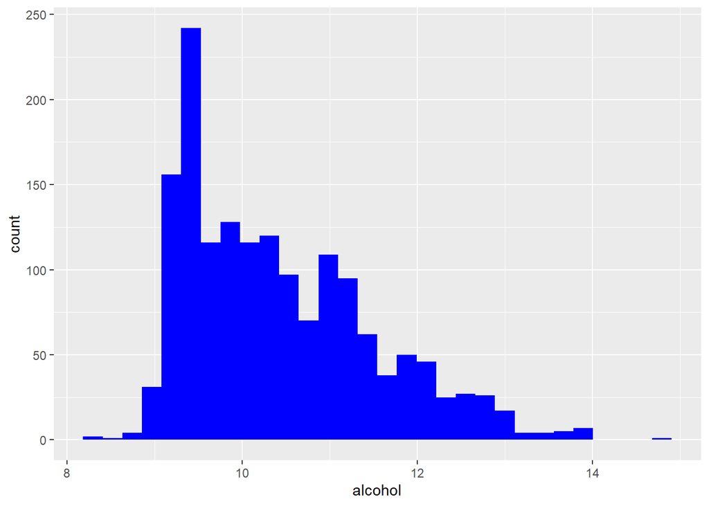

```r
ggplot(winequality, aes(x = alcohol)) + geom_histogram(fill = "blue", bindwith = 1)
```

#Most important numeric predictors

```r
numericVars <- which(sapply(winequality, is.numeric))
numericVarNames <- names(numericVars)
cat("There are", length(numericVars), "numeric variables")
```

```
## There are 12 numeric variables
```

# Creating the corrplot

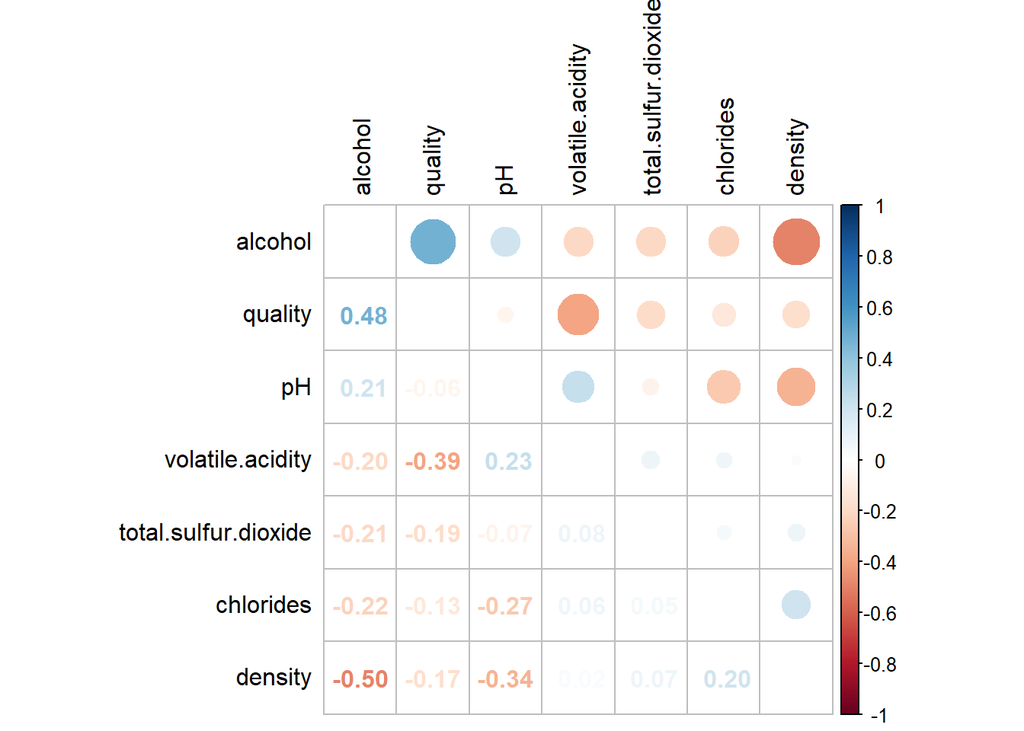

```r
all_numVar <- winequality[, numericVars]
cor_numVar <- cor(all_numVar, use = "pairwise.complete.obs")

#Sort on decreasing correlations with alcohol
cor_sorted <- as.matrix(sort(cor_numVar[,"alcohol"], decreasing = TRUE))

#Selecting high correlations
Cor_High <- names(which(apply(cor_sorted, 1, function(x) abs(x) > 0.175)))
cor_numVar <- cor_numVar[Cor_High, Cor_High]

corrplot.mixed(cor_numVar, tl.col = "black", tl.pos = "lt")
```

Since quality is interrelated with alcohol content, let’s try to create plots to relate to its relatability

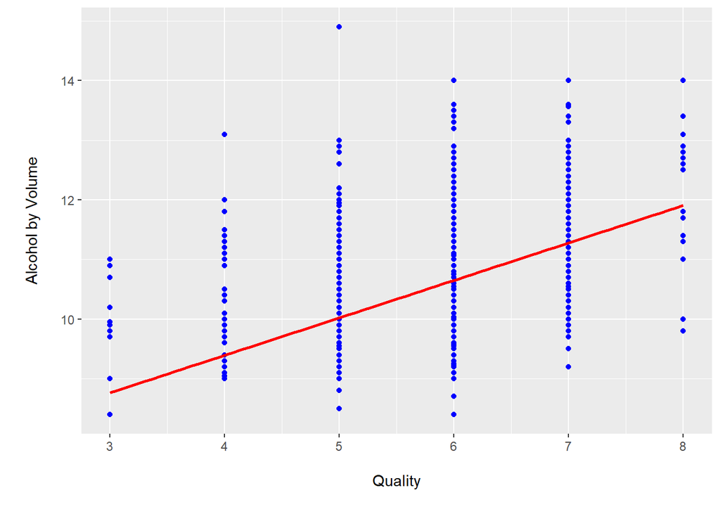

```r
ggplot(winequality, aes(x = quality, y = alcohol)) + geom_point(col = "blue") + labs(x = "\n Quality \n") + labs(y = "\n Alcohol by Volume \n") + geom_smooth(method = "lm", se = FALSE, color = "red", aes(group = 1))
```

#Determining full correlation between alcohol and the other variables

```r
cor(winequality$alcohol, winequality$fixed.acidity, use = "pairwise.complete.obs")
```

```
## [1] -0.06166827
```

```r
cor(winequality$alcohol, winequality$volatile.acidity, use = "pairwise.complete.obs")
```

```
## [1] -0.202288
```

```r
cor(winequality$alcohol, winequality$citric.acid, use = "pairwise.complete.obs")
```

```
## [1] 0.1099032
```

```r
cor(winequality$alcohol, winequality$residual.sugar, use = "pairwise.complete.obs")
```

```
## [1] 0.04207544
```

```r
cor(winequality$alcohol, winequality$chlorides, use = "pairwise.complete.obs")
```

```
## [1] -0.2211405
```

```r
cor(winequality$alcohol, winequality$free.sulfur.dioxide, use = "pairwise.complete.obs")
```

```
## [1] -0.06940835
```

```r
cor(winequality$alcohol, winequality$total.sulfur.dioxide, use = "pairwise.complete.obs")
```

```
## [1] -0.2056539
```

```r
cor(winequality$alcohol, winequality$density, use = "pairwise.complete.obs")
```

```
## [1] -0.4961798
```

```r
cor(winequality$alcohol, winequality$pH, use = "pairwise.complete.obs")
```

```
## [1] 0.2056325
```

```r
cor(winequality$alcohol, winequality$sulphates, use = "pairwise.complete.obs")
```

```
## [1] 0.09359475
```

```r
cor(winequality$alcohol, winequality$quality, use = "pairwise.complete.obs")
```

```
## [1] 0.4761663
```

#Visualizing with some of the other variables #alcohol with pH

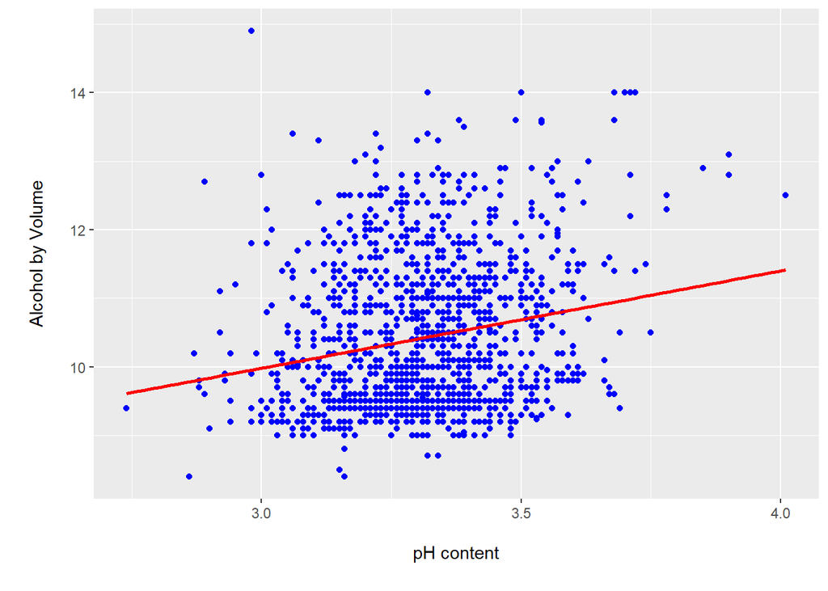

```r
ggplot(winequality, aes(x = pH, y = alcohol)) + geom_point(col = "blue") + labs(x = "\n pH content \n") + labs(y = "\n Alcohol by Volume \n") + geom_smooth(method = "lm", se = FALSE, color = "red", aes(group = 1))
```

# alcohol with citric acid

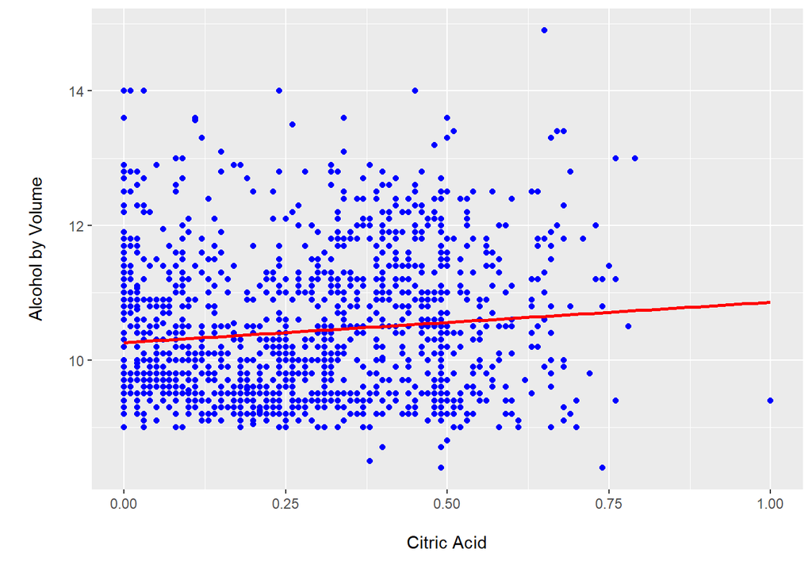

```r
ggplot(winequality, aes(x = citric.acid, y = alcohol)) + geom_point(col = "blue") + labs(x = "\n Citric Acid \n") + labs(y = "\n Alcohol by Volume \n") + geom_smooth(method = "lm", se = FALSE, color = "red", aes(group = 1))
```

# alcohol with fixed.acidity

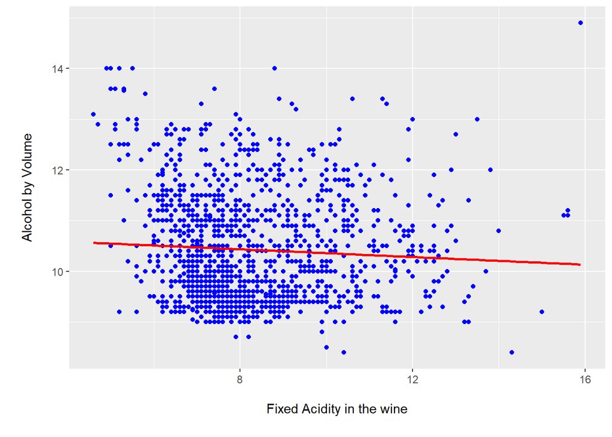

```r
ggplot(winequality, aes(x = fixed.acidity, y = alcohol)) + geom_point(col = "blue") + labs(x = "\n Fixed Acidity in the wine \n") + labs(y = "\n Alcohol by Volume \n") + geom_smooth(method = "lm", se = FALSE, color = "red", aes(group = 1))
```

#alcohol with volatile.acidity

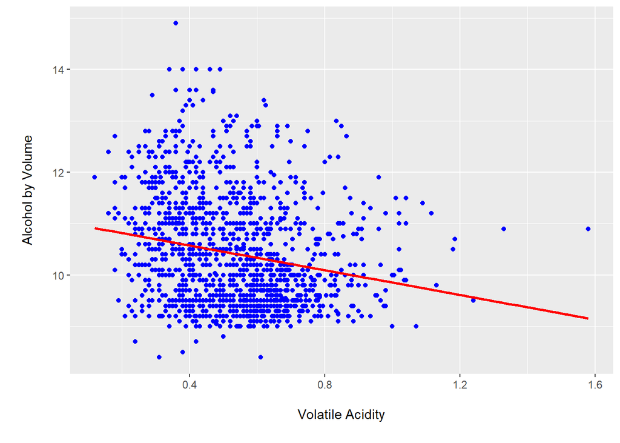

```r
ggplot(winequality, aes(x = volatile.acidity, y = alcohol)) + geom_point(col = "blue") + labs(x = "\n Volatile Acidity \n") + labs(y = "\n Alcohol by Volume \n") + geom_smooth(method = "lm", se = FALSE, color = "red", aes(group = 1))
```

#alcohol with residual.sugar

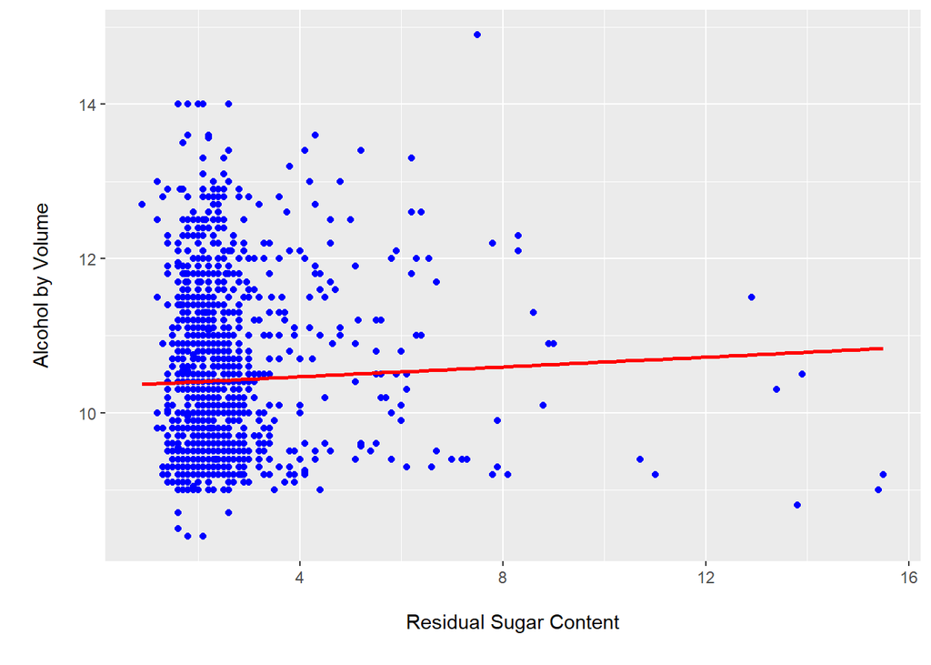

```r
ggplot(winequality, aes(x = residual.sugar, y = alcohol)) + geom_point(col = "blue") + labs(x = "\n Residual Sugar Content \n") + labs(y = "\n Alcohol by Volume \n") + geom_smooth(method = "lm", se = FALSE, color = "red", aes(group = 1))
```

#alcohol with chlorides

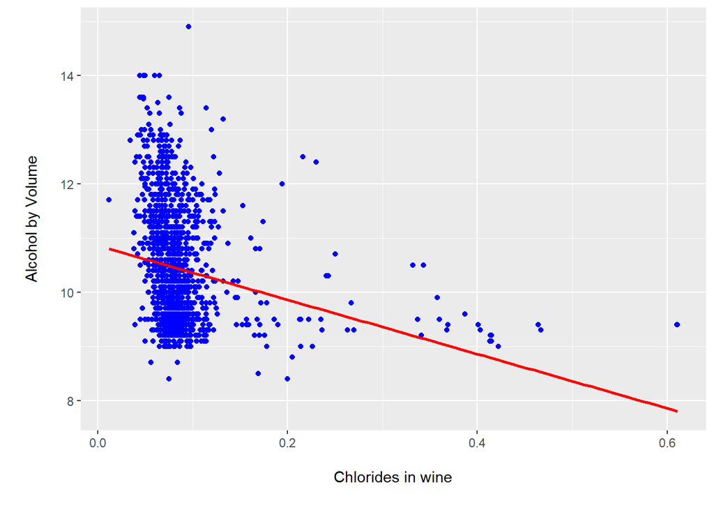

```r
ggplot(winequality, aes(x = chlorides, y = alcohol)) + geom_point(col = "blue") + labs(x = "\n Chlorides in wine \n") + labs(y = "\n Alcohol by Volume \n") + geom_smooth(method = "lm", se = FALSE, color = "red", aes(group = 1))
```

#alcohol with free.sulfur.dioxide

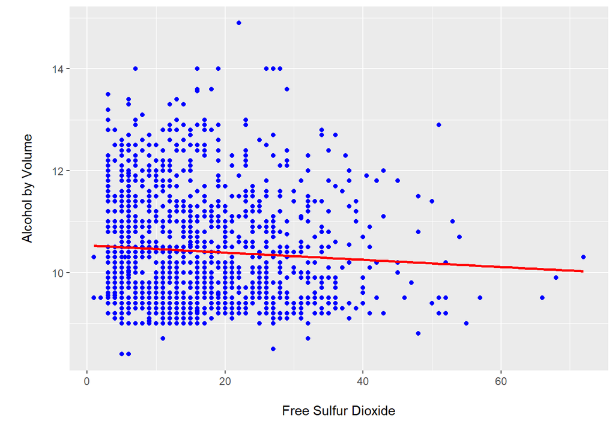

```r
ggplot(winequality, aes(x = free.sulfur.dioxide, y = alcohol)) + geom_point(col = "blue") + labs(x = "\n Free Sulfur Dioxide \n") + labs(y = "\n Alcohol by Volume \n") + geom_smooth(method = "lm", se = FALSE, color = "red", aes(group = 1))
```

#alcohol with total sulfur dioxide

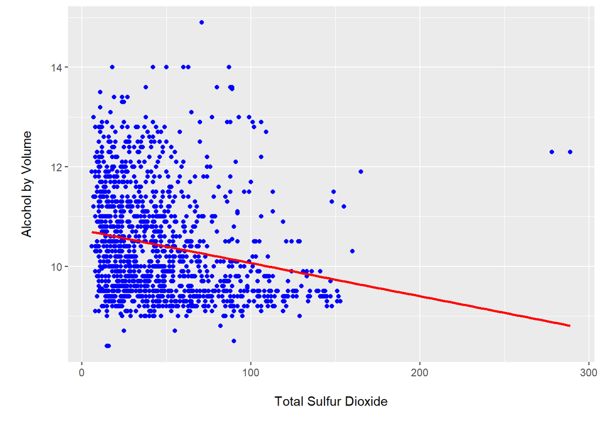

```r
ggplot(winequality, aes(x = total.sulfur.dioxide, y = alcohol)) + geom_point(col = "blue") + labs(x = "\n Total Sulfur Dioxide \n") + labs(y = "\n Alcohol by Volume \n") + geom_smooth(method = "lm", se = FALSE, color = "red", aes(group = 1))
```

#alcohol with density

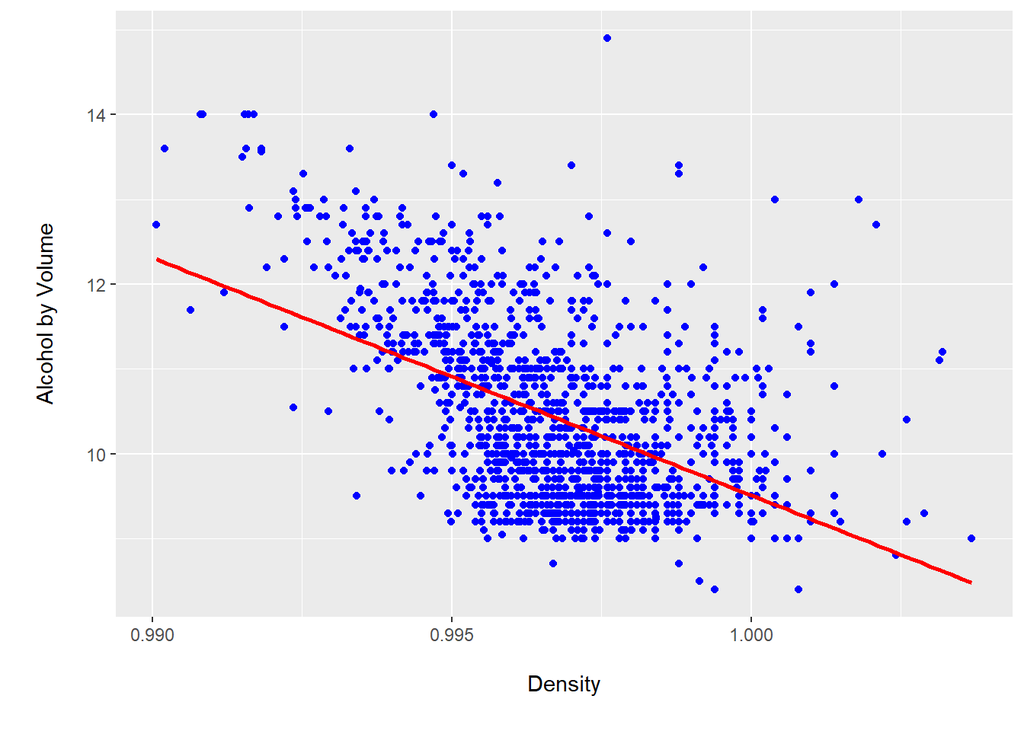

```r
ggplot(winequality, aes(x = density, y = alcohol)) + geom_point(col = "blue") + labs(x = "\n Density \n") + labs(y = "\n Alcohol by Volume \n") + geom_smooth(method = "lm", se = FALSE, color = "red", aes(group = 1))
```

#alcohol with sulphates

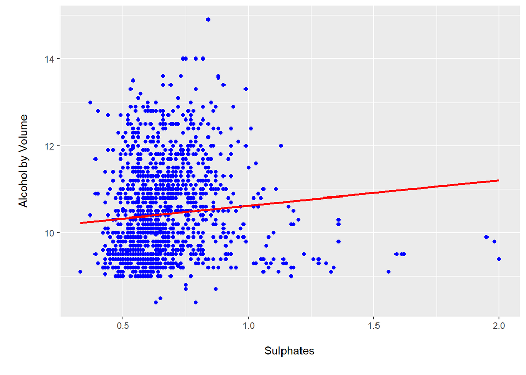

```r
ggplot(winequality, aes(x = sulphates, y = alcohol)) + geom_point(col = "blue") + labs(x = "\n Sulphates \n") + labs(y = "\n Alcohol by Volume \n") + geom_smooth(method = "lm", se = FALSE, color = "red", aes(group = 1))
```

#Creating the Machine Learning Model (via a 1:68 ratio)

```r
# Via keras

index <- 1:68

training <- winequality[index,]
testing <- winequality[-index,]
```

#Conducting Z-score scaling This is used to convert all the indicators to a common scale with an average of zero and an SD (standard deviation of 1)

```r
# using dplyr to keep the data frame structure

training %>%
  mutate_at(vars(-alcohol), scale) -> training

testing %>%
  mutate_at(vars(-alcohol), scale) -> testing
```

#GLM and LM Assuming normal distribution with linear modelling

```r
fit_lm <- lm(alcohol~., data = training)
```

```r
summary(fit_lm)
```

```
##
## Call:
## lm(formula = alcohol ~ ., data = training)
##
## Residuals:
##      Min       1Q   Median       3Q      Max
## -0.83866 -0.23803 -0.02415  0.23247  1.08064
##
## Coefficients:
##                       Estimate Std. Error t value Pr(>|t|)
## (Intercept)           9.742647   0.057811 168.526  < 2e-16 ***
## fixed.acidity         0.449559   0.118625   3.790 0.000371 ***
## volatile.acidity     -0.002071   0.081793  -0.025 0.979890
## citric.acid          -0.048029   0.099483  -0.483 0.631131
## residual.sugar        0.382498   0.079485   4.812 1.17e-05 ***
## chlorides             0.095248   0.076015   1.253 0.215402
## free.sulfur.dioxide  -0.220998   0.107077  -2.064 0.043670 *
## total.sulfur.dioxide  0.232396   0.112478   2.066 0.043451 *
## density              -0.538144   0.105449  -5.103 4.13e-06 ***
## pH                    0.530512   0.095132   5.577 7.34e-07 ***
## sulphates             0.169999   0.077449   2.195 0.032327 *
## quality               0.058302   0.067585   0.863 0.392011
## ---
## Signif. codes:  0 '***' 0.001 '**' 0.01 '*' 0.05 '.' 0.1 ' ' 1
##
## Residual standard error: 0.4767 on 56 degrees of freedom
## Multiple R-squared:  0.5413, Adjusted R-squared:  0.4512
## F-statistic: 6.008 on 11 and 56 DF,  p-value: 2.273e-06
```

#Making predictions

```r
pred_lm <- predict(fit_lm, newdata = testing)
print(head(pred_lm))
```

```
##        69        70        71        72        73        74
##  9.580194 10.056112  9.261647  9.757964  9.655916  9.198002
```

#Using Random Forests

```r
fit_rf <- randomForest(alcohol~., data = training)
summary(fit_rf)
```

```
##                 Length Class  Mode
## call              3    -none- call
## type              1    -none- character
## predicted        68    -none- numeric
## mse             500    -none- numeric
## rsq             500    -none- numeric
## oob.times        68    -none- numeric
## importance       11    -none- numeric
## importanceSD      0    -none- NULL
## localImportance   0    -none- NULL
## proximity         0    -none- NULL
## ntree             1    -none- numeric
## mtry              1    -none- numeric
## forest           11    -none- list
## coefs             0    -none- NULL
## y                68    -none- numeric
## test              0    -none- NULL
## inbag             0    -none- NULL
## terms             3    terms  call
```

# Making predictions

```r
pred_rf <- predict(fit_rf, newdata = testing)
print(head(pred_rf))
```

```
##       69       70       71       72       73       74
## 9.673363 9.903213 9.610653 9.748653 9.736843 9.611773
```

#Using rpart

```r
fit_rpart <- rpart(alcohol~., data = training)
summary(fit_rpart)
```

```
## Call:
## rpart(formula = alcohol ~ ., data = training)
##   n= 68
##
##           CP nsplit rel error   xerror      xstd
## 1 0.10542269      0 1.0000000 1.011671 0.4096542
## 2 0.07700208      2 0.7891546 1.375812 0.4397455
## 3 0.01839583      3 0.7121525 1.397802 0.4679580
## 4 0.01124874      4 0.6937567 1.465715 0.4939963
## 5 0.01000000      5 0.6825080 1.465715 0.4939963
##
## Variable importance
##        fixed.acidity                   pH total.sulfur.dioxide
##                   19                   16                   15
##       residual.sugar  free.sulfur.dioxide            sulphates
##                   13                   13                    9
##     volatile.acidity            chlorides              density
##                    5                    5                    4
##          citric.acid
##                    3
##
## Node number 1: 68 observations,    complexity param=0.1054227
##   mean=9.742647, MSE=0.4080342
##   left son=2 (32 obs) right son=3 (36 obs)
##   Primary splits:
##       residual.sugar      < -0.3851022  to the left,  improve=0.09735288, (0 missing)
##       pH                  < 0.5066794   to the left,  improve=0.09028939, (0 missing)
##       free.sulfur.dioxide < -0.6384226  to the right, improve=0.07865554, (0 missing)
##       fixed.acidity       < -0.1965207  to the right, improve=0.06461399, (0 missing)
##       volatile.acidity    < -0.7092581  to the left,  improve=0.05595141, (0 missing)
##   Surrogate splits:
##       free.sulfur.dioxide  < 0.09273928  to the left,  agree=0.662, adj=0.281, (0 split)
##       total.sulfur.dioxide < 0.2919729   to the left,  agree=0.662, adj=0.281, (0 split)
##       density              < 0.1417103   to the left,  agree=0.662, adj=0.281, (0 split)
##       sulphates            < -0.3240484  to the left,  agree=0.662, adj=0.281, (0 split)
##       volatile.acidity     < -1.257321   to the left,  agree=0.632, adj=0.219, (0 split)
##
## Node number 2: 32 observations,    complexity param=0.01839583
##   mean=9.53125, MSE=0.1271484
##   left son=4 (24 obs) right son=5 (8 obs)
```

[output cut: 63 more lines]

```
##       free.sulfur.dioxide  < -1.004004   to the right, agree=0.759, adj=0.3, (0 split)
##       volatile.acidity     < -0.8006019  to the right, agree=0.724, adj=0.2, (0 split)
##       total.sulfur.dioxide < -1.136384   to the right, agree=0.724, adj=0.2, (0 split)
##
## Node number 8: 9 observations
##   mean=9.311111, MSE=0.02098765
##
## Node number 9: 15 observations
##   mean=9.546667, MSE=0.1064889
##
## Node number 14: 19 observations
##   mean=9.878947, MSE=0.2342936
##
## Node number 15: 10 observations
##   mean=10.45, MSE=1.1105
```

#Making predictions

```r
pred_rpart <- predict(fit_rpart, data = testing)
print(head(pred_rpart))
```

```
##        1        2        3        4        5        6
## 9.546667 9.878947 9.878947 9.546667 9.546667 9.546667
```

# Creating the Machine Learning Model (via a 1:225 ratio)

```r
# Via keras

index <- 1:225

training <- winequality[index,]
testing <- winequality[-index,]
```

#Conducting Z-score scaling This is used to convert all the indicators to a common scale with an average of zero and an SD (standard deviation of 1)

```r
# using dplyr to keep the data frame structure

training %>%
  mutate_at(vars(-alcohol), scale) -> training

testing %>%
  mutate_at(vars(-alcohol), scale) -> testing
```

#GLM and LM Assuming normal distribution with linear modelling

```r
fit_lm <- lm(alcohol~., data = training)
summary(fit_lm)
```

```
##
## Call:
## lm(formula = alcohol ~ ., data = training)
##
## Residuals:
##      Min       1Q   Median       3Q      Max
## -0.98355 -0.28598 -0.01677  0.26521  1.41122
##
## Coefficients:
##                      Estimate Std. Error t value Pr(>|t|)
## (Intercept)           9.86044    0.03049 323.397  < 2e-16 ***
## fixed.acidity         0.66448    0.06189  10.736  < 2e-16 ***
## volatile.acidity      0.02080    0.04066   0.511   0.6096
## citric.acid           0.02288    0.05043   0.454   0.6505
## residual.sugar        0.37095    0.03837   9.667  < 2e-16 ***
## chlorides             0.09361    0.04441   2.108   0.0362 *
## free.sulfur.dioxide  -0.08615    0.04822  -1.786   0.0754 .
## total.sulfur.dioxide  0.08760    0.05255   1.667   0.0970 .
## density              -0.80988    0.04964 -16.314  < 2e-16 ***
## pH                    0.65665    0.05289  12.415  < 2e-16 ***
## sulphates             0.32082    0.04146   7.739 3.98e-13 ***
## quality               0.07363    0.03542   2.079   0.0388 *
## ---
## Signif. codes:  0 '***' 0.001 '**' 0.01 '*' 0.05 '.' 0.1 ' ' 1
##
## Residual standard error: 0.4574 on 213 degrees of freedom
## Multiple R-squared:  0.7118, Adjusted R-squared:  0.6969
## F-statistic: 47.82 on 11 and 213 DF,  p-value: < 2.2e-16
```

#Making predictions

```r
pred_lm <- predict(fit_lm, newdata = testing)
print(head(pred_lm))
```

```
##       226       227       228       229       230       231
##  9.886869 11.564626  9.666262  9.886869  9.536556 11.155681
```

#Using Random Forests

```r
fit_rf <- randomForest(alcohol~., data = training)
summary(fit_rf)
```

```
##                 Length Class  Mode
## call              3    -none- call
## type              1    -none- character
## predicted       225    -none- numeric
## mse             500    -none- numeric
## rsq             500    -none- numeric
## oob.times       225    -none- numeric
## importance       11    -none- numeric
## importanceSD      0    -none- NULL
## localImportance   0    -none- NULL
## proximity         0    -none- NULL
## ntree             1    -none- numeric
## mtry              1    -none- numeric
## forest           11    -none- list
## coefs             0    -none- NULL
## y               225    -none- numeric
## test              0    -none- NULL
## inbag             0    -none- NULL
## terms             3    terms  call
```

#Making predictions

```r
pred_rf <- predict(fit_rf, newdata = testing)
print(head(pred_rf))
```

```
##       226       227       228       229       230       231
##  9.691180  9.694123  9.877537  9.691180  9.947830 11.225277
```

#Using rpart

```r
fit_rpart <- rpart(alcohol~., data = training)
summary(fit_rpart)
```

```
## Call:
## rpart(formula = alcohol ~ ., data = training)
##   n= 225
##
##           CP nsplit rel error    xerror      xstd
## 1 0.54836040      0 1.0000000 1.0135754 0.2132845
## 2 0.04065114      1 0.4516396 0.7473829 0.1351274
## 3 0.02945180      3 0.3703373 0.7568467 0.1260223
## 4 0.02528749      4 0.3408855 0.7826471 0.1285572
## 5 0.01943126      5 0.3155980 0.7805591 0.1292025
## 6 0.01544266      6 0.2961668 0.7651692 0.1321584
## 7 0.01079156      8 0.2652814 0.7461191 0.1307999
## 8 0.01000000      9 0.2544899 0.7385102 0.1298836
##
## Variable importance
##              density                   pH        fixed.acidity
##                   35                   27                   18
##            chlorides       residual.sugar              quality
##                   10                    4                    2
##     volatile.acidity          citric.acid  free.sulfur.dioxide
##                    2                    1                    1
## total.sulfur.dioxide
##                    1
##
## Node number 1: 225 observations,    complexity param=0.5483604
##   mean=9.860444, MSE=0.6870131
##   left son=2 (218 obs) right son=3 (7 obs)
##   Primary splits:
##       density       < -2.477135    to the right, improve=0.54836040, (0 missing)
##       pH            < 1.840165     to the left,  improve=0.43997010, (0 missing)
##       chlorides     < -0.6036888   to the right, improve=0.40291920, (0 missing)
##       fixed.acidity < -1.776383    to the right, improve=0.33670400, (0 missing)
##       quality       < 0.3179487    to the left,  improve=0.07395322, (0 missing)
##   Surrogate splits:
##       pH            < 1.840165     to the left,  agree=0.991, adj=0.714, (0 split)
##       fixed.acidity < -1.906053    to the right, agree=0.982, adj=0.429, (0 split)
##       chlorides     < -0.6472427   to the right, agree=0.978, adj=0.286, (0 split)
##
## Node number 2: 218 observations,    complexity param=0.04065114
##   mean=9.750459, MSE=0.3136007
```

[output cut: 127 more lines]

```
##   left son=66 (65 obs) right son=67 (7 obs)
##   Primary splits:
##       fixed.acidity    < -0.6525764   to the right, improve=0.24280860, (0 missing)
##       density          < -0.1065914   to the right, improve=0.14972050, (0 missing)
##       citric.acid      < -0.3222964   to the right, improve=0.09988751, (0 missing)
##       volatile.acidity < 0.3210307    to the left,  improve=0.09199836, (0 missing)
##       chlorides        < 0.2310936    to the right, improve=0.06059535, (0 missing)
##   Surrogate splits:
##       density < -0.68321     to the right, agree=0.944, adj=0.429, (0 split)
##
## Node number 66: 65 observations
##   mean=9.550769, MSE=0.1372686
##
## Node number 67: 7 observations
##   mean=10.3, MSE=0.3057143
```

# Making predictions

```r
pred_rpart <- predict(fit_rpart, data = testing)
print(head(pred_rpart))
```

```
##        1        2        3        4        5        6
## 9.430000 9.550769 9.550769 9.971429 9.430000 9.430000
```

#Creating the Machine Learning Model (via a 1:404 ratio)

```r
# Via keras

index <- 1:404

training <- winequality[index,]
testing <- winequality[-index,]
```

#Conducting Z-score scaling This is used to convert all the indicators to a common scale with an average of zero and an SD (standard deviation of 1)

```r
# using dplyr to keep the data frame structure

training %>%
  mutate_at(vars(-alcohol), scale) -> training

testing %>%
  mutate_at(vars(-alcohol), scale) -> testing
```

#GLM and LM Assuming normal distribution with linear modelling

```r
fit_lm <- lm(alcohol~., data = training)
summary(fit_lm)
```

```
##
## Call:
## lm(formula = alcohol ~ ., data = training)
##
## Residuals:
##      Min       1Q   Median       3Q      Max
## -1.81798 -0.35116 -0.03091  0.29824  2.33232
##
## Coefficients:
##                       Estimate Std. Error t value Pr(>|t|)
## (Intercept)          10.004703   0.030245 330.785  < 2e-16 ***
## fixed.acidity         0.927479   0.079499  11.667  < 2e-16 ***
## volatile.acidity      0.171757   0.038815   4.425 1.25e-05 ***
## citric.acid           0.256423   0.053093   4.830 1.96e-06 ***
## residual.sugar        0.384951   0.037779  10.190  < 2e-16 ***
## chlorides            -0.003751   0.040195  -0.093    0.926
## free.sulfur.dioxide   0.058801   0.046428   1.267    0.206
## total.sulfur.dioxide -0.035198   0.050481  -0.697    0.486
## density              -0.972462   0.058972 -16.490  < 2e-16 ***
## pH                    0.614660   0.049946  12.306  < 2e-16 ***
## sulphates             0.224617   0.038010   5.909 7.46e-09 ***
## quality               0.164825   0.036350   4.534 7.69e-06 ***
## ---
## Signif. codes:  0 '***' 0.001 '**' 0.01 '*' 0.05 '.' 0.1 ' ' 1
##
## Residual standard error: 0.6079 on 392 degrees of freedom
## Multiple R-squared:  0.5819, Adjusted R-squared:  0.5701
## F-statistic: 49.59 on 11 and 392 DF,  p-value: < 2.2e-16
```

#Making predictions

```r
pred_lm <- predict(fit_lm, newdata = testing)
print(head(pred_lm))
```

```
##       405       406       407       408       409       410
##  8.791028 10.397569 10.002018 10.720441 11.119333 10.829255
```

#Using Random Forests

```r
fit_rf <- randomForest(alcohol~., data = training)
summary(fit_rf)
```

```
##                 Length Class  Mode
## call              3    -none- call
## type              1    -none- character
## predicted       404    -none- numeric
## mse             500    -none- numeric
## rsq             500    -none- numeric
## oob.times       404    -none- numeric
## importance       11    -none- numeric
## importanceSD      0    -none- NULL
## localImportance   0    -none- NULL
## proximity         0    -none- NULL
## ntree             1    -none- numeric
## mtry              1    -none- numeric
## forest           11    -none- list
## coefs             0    -none- NULL
## y               404    -none- numeric
## test              0    -none- NULL
## inbag             0    -none- NULL
## terms             3    terms  call
```

#Making predictions

```r
pred_rf <- predict(fit_rf, newdata = testing)
print(head(pred_rf))
```

```
##       405       406       407       408       409       410
##  9.735913 10.315513 10.224290 10.783283 11.189080 10.228783
```

#Using rpart

```r
fit_rpart <- rpart(alcohol~., data = training)
summary(fit_rpart)
```

```
## Call:
## rpart(formula = alcohol ~ ., data = training)
##   n= 404
##
##            CP nsplit rel error    xerror       xstd
## 1  0.26551278      0 1.0000000 1.0059216 0.11466963
## 2  0.09993838      1 0.7344872 0.7612696 0.08292159
## 3  0.07959527      2 0.6345488 0.7114145 0.07291289
## 4  0.04193728      3 0.5549536 0.6353631 0.06817107
## 5  0.03363574      4 0.5130163 0.6722028 0.07273693
## 6  0.02677397      5 0.4793806 0.7027748 0.07720498
## 7  0.02196944      7 0.4258326 0.6821352 0.07023388
## 8  0.01803339      8 0.4038632 0.6925622 0.07167210
## 9  0.01425183      9 0.3858298 0.6855925 0.07143980
## 10 0.01160488     10 0.3715779 0.6806358 0.07289773
## 11 0.01121726     11 0.3599731 0.6719272 0.07215715
## 12 0.01000000     12 0.3487558 0.6677906 0.07186609
##
## Variable importance
##              density        fixed.acidity            chlorides
##                   33                   19                   10
##       residual.sugar          citric.acid              quality
##                   10                    9                    7
##                   pH            sulphates     volatile.acidity
##                    7                    3                    1
##  free.sulfur.dioxide total.sulfur.dioxide
##                    1                    1
##
## Node number 1: 404 observations,    complexity param=0.2655128
##   mean=10.0047, MSE=0.8576264
##   left son=2 (394 obs) right son=3 (10 obs)
##   Primary splits:
##       density       < -2.162008    to the right, improve=0.2655128, (0 missing)
##       chlorides     < -0.6432698   to the right, improve=0.2139378, (0 missing)
##       fixed.acidity < -1.536186    to the right, improve=0.1652380, (0 missing)
##       quality       < 1.308589     to the left,  improve=0.1157122, (0 missing)
##       pH            < 1.410481     to the left,  improve=0.1021172, (0 missing)
##   Surrogate splits:
##       fixed.acidity < -1.536186    to the right, agree=0.988, adj=0.5, (0 split)
##       chlorides     < -0.7058315   to the right, agree=0.983, adj=0.3, (0 split)
```

[output cut: 187 more lines]

```
##   Surrogate splits:
##       sulphates            < -0.2451617   to the left,  agree=0.826, adj=0.6, (0 split)
##       citric.acid          < 1.000993     to the left,  agree=0.783, adj=0.5, (0 split)
##       residual.sugar       < -0.00989465  to the left,  agree=0.696, adj=0.3, (0 split)
##       chlorides            < -0.228799    to the left,  agree=0.696, adj=0.3, (0 split)
##       total.sulfur.dioxide < -1.084503    to the left,  agree=0.696, adj=0.3, (0 split)
##
## Node number 163: 23 observations
##   mean=10.5, MSE=0.3121739
##
## Node number 324: 10 observations
##   mean=9.44, MSE=0.0484
##
## Node number 325: 13 observations
##   mean=10.26923, MSE=0.5744379
```

# Making predictions

```r
pred_rpart <- predict(fit_rpart, data = testing)
print(head(pred_rpart))
```

```
##        1        2        3        4        5        6
## 9.526708 9.724242 9.526708 9.839216 9.526708 9.526708
```